# PCA on dataset HDR

Principal Component Analysis (PCA) checks whether information in a set of variables can be expressed through a reduced set of new variables or principal components.It’s the simplest data compression technique.

PCA works only with numeric values and with no NAs. What is non-numeric or NA, needs to be removed from the file.

1. Here, we want to run a PCA using only 3 variables from dataset HDR: lifespan, schoolingyears and GNI. This is the result of the PCA:

```r
pcaHDR
```

```
Standard deviations (1, .., p=3):
[1] 1.4939609 0.7093123 0.5147397

Rotation (n x k) = (3 x 3):
                      PC1        PC2        PC3
lifespan       -0.6037158  0.2759721  0.7479082
schoolingyears -0.5881280  0.4791588 -0.6515461
GNI            -0.5381753 -0.8332144 -0.1269688
```

2. We can write down the equation describing PC1: PC1 = -0.60(lifespan)-0.58(schoolingyears)-0.53(GNI)

c.Each case in the dataset has a specific PC1. For example, for case1:

```r
Pc1Country1
```

```
[1] -25261.18
```

4. Now, based on the PCA result, we want to decide how many PCs should be kept. There’s a retention criteria that claims that, if lambdai related to PCi is > 1, then PCi should be kept. So, we have to look at variance lambda, for each PCi.

```r
variances
```

```
[1] 2.2319191 0.5031239 0.2649570
```

Only PC1 has a lambda > 1, so PC1 is the only one that should be kept.

5. This is also confirmed by the screeplot:

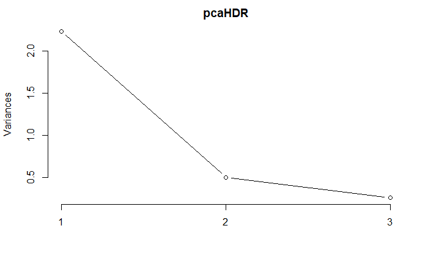

6. Keeping only PC1 does make sense, because 74,4% of variance is explained by this new component.

```r
summary(pcaHDR)
```

```
Importance of components:
                         PC1    PC2     PC3
Standard deviation     1.494 0.7093 0.51474
Proportion of Variance 0.744 0.1677 0.08832
Cumulative Proportion  0.744 0.9117 1.00000
```

What is the final advantage of using PCA, here? We had 3 original variables, now we need only one to explain them all, PC1.

What’s the interpretation of PC1? A country with high lifespan, high schooling years, and GNI has a really negative PC1. Therefore, this axis can be called poverty, or underdevelopment.